# Quiz1대비(3)

김재현

2023-10-20

### 실험단위, 독립변수, 종속변수

*문제*  
정부의 정책적 지원을 받은 중소기업과 받지 않은 중소기업을 대상으로 수익률을 조사하였다.  
실험단위는? 독립변수는? 종속변수는?

**답**  
실험단위 : 중소기업 (**독립변수에 적용되는 연구 대상이 되는 개체**)  
독립변수 : 정책적 지원 수령 유무  
종속변수 : 수익률

### 솔로몬 4그룹 순수 실험 설계

**사전지식**

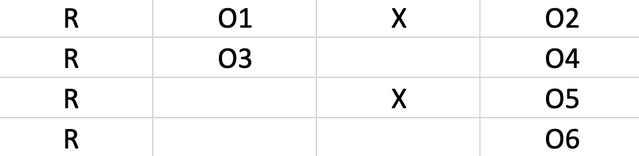

R : Randomization  
O : observation  
X : Treatment

사전 측정이 없는 경우엔 학습효과가 없다.(학습효과는 사전 측정으로 학습한 것을 사후 측정에 적용하는 것이므로)

학습효과가 없다면 상호작용효과도 없다.(상호작용효과는 처리효과와 학습효과의 상호작용에 의한 것이기 때문에, 반대로 처리효과가 없어도 상호작용효과는 없을 것이다.)

O2-O1(=E1) = 처리효과 + 학습효과 + 상호작용효과 + 다른 혼란변수

O4-O3(=E2) = 학습효과 + 다른 혼란변수  
*처리X가 없으므로 처리효과가 없다. 뿐만 아니라 상호작용효과도 없다.*

O6-(O1과O3의 평균값)(=E4) = 다른 혼란변수

**상호작용 학습효과 측정하기** E1-E3 = 학습효과 + 상호작용효과  
E2-E4 = 학습효과  
(E1-E3)-(E2-E4) = 상호작용효과

*문제*  
솔로몬 4그룹 순수실험설계에서 나타난 결과이다. 지원 정책을 적용한 그룹의 학습효과와 지원정책을 적용하지 않은 그룹의 학습효과를 계산하고 지원정책의 효과와 학습효과간의 상호작용효과를 계산하시오

R 10 지원정책 적용 15  
R 12 지원정책 비적용 13  
R 지원정책 적용 18  
R 지원정책 비적용 15

**답**  
E1 = 5 처리효과 + 학습효과 + 상호작용효과 + 혼란변수  
E2 = 1 학습효과 + 혼란변수  
E3 = 18-[(10+12)/2] = 7 처리효과 + 혼란변수  
E4 = 15-[(10+12)/2] = 4 혼란변수

*지원 정책을 적용한 그룹의 학습효과*  
E1 - E3 = 5-7 = -2

*지원 정책을 적용하지 않은 그룹의 학습효과*  
E2 - E4 = 1-4 = -3

**지원정책의 효과와 학습효과간의 상호작용효과**  
(E1-E3) - (E2-E4) = 1

### 랜덤화과정 vs 랜덤샘플링

랜덤화과정(randomization process)는 실험단위를 난수표에 의하여 실험그룹이나 대조그룹으로 할당하는 과정을 말한다. 랜덤화 과정은 혼란변수에 의한 효과를 처리효과와 분리시킨다. 혼란변수에 의한 효과는 오차에 들어가도록 만든다.  
랜덤화과정은 실험그룹과 대조그룹이 서로 차이가 나지 않도록 하는 것으로, **내적 타당성** 문제와 관련되어 있다.

랜덤샘플링(Random sampling)은 모집단에 속해있는 실험단위를 어떻게 표본으로 선정할 것인가에 초점이 맞춰져있다. 연구자는 랜덤샘플링을 통해 모집단의 특성을 잘 대표할 수 있는 표본을 선택하고자 한다. 이는 **외적 타당성**을 높이는 문제와 관련되어 있다.

### 블록(block)이란?

비슷한 성질을 갖는 연구대상을 모아놓은 그룹 ex) 50명의 학새을 선택하는 과정에서 25명은 남학생, 25명은 여학생으로 구성 –> 성별에 의하여 구분된 두 그룹은 블록을 형성했다.

Within Variance와 어떤 관계? -> Within Variance(그룹내 분산)는 ANOVA에서 확인.

### 라틴스퀘어 실험설계

*문제*

A라는 요인이 A1, A2. A3의 수준을 가지고 있고, B라는 요인이 B1, B2, B3의 수준을 가지고 있으며, C라는 요인이 C1. C2, C3의 수준을 가지고 있을 경우, (A1. B1, C1) 조합으로 시작하는 9개로 구성된 라틴 어 실험설계의 나머지 8개, 조합을 제시하시오.

**답**

라틴 스퀘어를 그려보면…

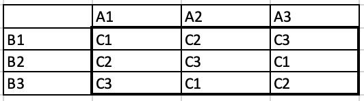

라틴스퀘어에서 중요한 건 **모든 행이나 열에 [열,행이 아닌 요인 = 위에선 C요인]의 수준은 한번씩만 나타난다!**

조합은 다음과 같다.(물론 다른 경우도 더 나올 수 있다.) (A1,B1,C1) (A1,B2,C2) (A1,B3,C3) (A2,B1,C2) (A2,B2,C3) (A2,B3,C1) (A3,B1,C3) (A3,B2,C1) (A3,B3,C2)